# MobQoL OPUF value set GP vs MI

# 1 Setup

```r
rm(list=ls())

set.seed(2022)

library(jsonlite)
library(ggplot2)
library(presize)
library(reshape2)

library(knitr)

# load utility functions
source("./mobqol_util.R")

# define dimension ID
ds_dims = c("AC","CO","PD","IN","SE","ME","AX")

# load eligible id
eligible_ids_gp = read.csv("GP.csv")$Survey.ID
eligible_ids_mi = read.csv("MI.csv")$Survey.ID
# load raw response data
mq_jsons = read_json("raw_responses.json")
# retrieve and process data from JSON
gp = retrieveMobQoLPUFs(mq_jsons, eligible_ids = eligible_ids_gp)
mi = retrieveMobQoLPUFs(mq_jsons, eligible_ids = eligible_ids_mi)
```

# 2 Descriptive stats

Number of participants included in the analysis: **504** in the GP group; and **253** in the MI group.

# 3 demographic characteristics

| Group | GP | MI |
| --- | --- | --- |
| gender |  |  |
| female | 256 (50.8%) | 118 (46.6%) |
| male | 244 (48.4%) | 127 (50.2%) |
| other | 1 (0.2%) | 7 (2.8%) |
| preferNotToSay | 3 (0.6%) | 1 (0.4%) |
| age |  |  |
| 18-29 | 99 (19.6%) | 24 (9.5%) |
| 30-39 | 94 (18.7%) | 49 (19.4%) |
| 40-49 | 92 (18.3%) | 47 (18.6%) |
| 50-59 | 103 (20.4%) | 59 (23.3%) |
| 60-69 | 95 (18.8%) | 62 (24.5%) |
| 70+ | 15 (3%) | 10 (4%) |
| preferNotToSay | 6 (1.2%) | 2 (0.8%) |
| any_mobility_problems |  |  |
| false | 356 (70.6%) |  |
| preferNotToSay | 16 (3.2%) |  |
| true | 132 (26.2%) | 253 (100%) |
| mobility_problems_meq_6m |  |  |
| false | 19 (14.2%) |  |
| true | 115 (85.8%) | 253 (100%) |

# 4 Survey completion times

Mean completion time in the GP group = **9.3 minutes (SD = 6)**

Mean completion time in the MI group = **10.3 minutes (SD = 6)**

Completion time (mins)

|  | GP | MI |
| --- | --- | --- |
| Min. | 3.0 | 3.6 |
| 1st Qu. | 6.1 | 7.2 |
| Median | 8.0 | 9.2 |
| Mean | 9.3 | 10.3 |
| 3rd Qu. | 10.4 | 11.6 |
| Max. | 81.1 | 69.1 |

# 5 Own health state

Reported health state profiles

|  | GP | MI |
| --- | --- | --- |
| No problems | 238 (47%) | 0 (0%) |
| Only minor | 211 (42%) | 69 (27%) |
| Severe in at least 1 | 11 (2%) | 72 (28%) |
| Mean (SD) severity score | 9.3 (3.2) | 16.7 (4) |

N.B. Minimum severity score = 7

# 6 OPUF responses

# 7 Dimension weights

|  | GP Mean (SD) | GP Rank | MI Mean (SD) | MI Rank |
| --- | --- | --- | --- | --- |
| AC | 84.7 (23.1) | 2 | 79 (26.5) | 2 |
| AX | 64.3 (30.9) | 6 | 61.3 (31.6) | 7 |
| CO | 71.9 (27.2) | 5 | 76.6 (26.7) | 3 |
| IN | 73.9 (26.8) | 3 | 72.4 (27.7) | 4 |
| ME | 72 (28.2) | 4 | 70.4 (28.7) | 5 |
| PD | 88.3 (20.3) | 1 | 86.6 (22.7) | 1 |
| SE | 62.7 (31.2) | 7 | 62.2 (29.8) | 6 |

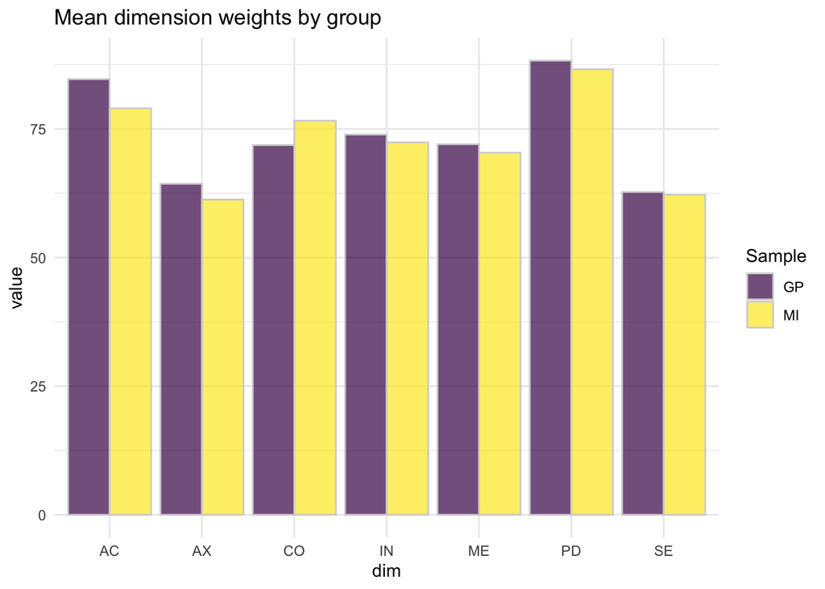

# 8 Level ratings

|  | GP Mean (SD) | MI Mean (SD) |
| --- | --- | --- |
| AC |  |  |
| lvl2 | 57.1 (24.9) | 55.2 (24.3) |
| lvl3 | 29.6 (26.5) | 32.6 (26.8) |
| CO |  |  |
| lvl2 | 55.2 (22.3) | 53.5 (21.4) |
| lvl3 | 32.9 (22.9) | 34.8 (22.9) |
| PD |  |  |
| lvl2 | 57.5 (24.8) | 56.7 (24.1) |
| lvl3 | 30.9 (28.2) | 32 (27) |
| IN |  |  |
| lvl2 | 72.9 (18.7) | 61.9 (26.8) |
| lvl3 | 43.9 (20) | 41.6 (19) |
| SE |  |  |
| lvl2 | 53 (24.5) | 53.6 (22) |
| lvl3 | 32.9 (24.2) | 35.2 (24.9) |
| ME |  |  |
| lvl2 | 52.9 (22.8) | 54.1 (21.8) |
| lvl3 | 32 (23.2) | 34.2 (24.6) |
| AX |  |  |
| lvl2 | 55.5 (26) | 54.4 (24.8) |
| lvl3 | 29 (24.2) | 32.2 (25.3) |

# 9 Anchoring

In the **GP** group, **331 (66%)** Participants indicated they would prefer the worst state over being dead. Correspondingly, **173 (34%)** Participants indicated they would prefer being dead over the worst state or be indifferent.

In the **MI** group, **181 (72%)** Participants indicated they would prefer the worst state over being dead. Correspondingly, **72 (28%)** Participants indicated they would prefer being dead over the worst state or be indifferent.

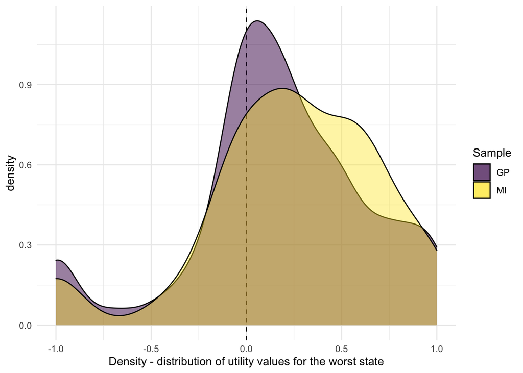

After capping utlity scale at -1 (which is commonly done), the mean (SD) anchor point (i.e. the utility of the worst health state) was **0.171 (0.472)** in the GP group, and **0.242 (0.47)** in the MI group.

N.B. In the GP group, 29 (6 %) participants had anchor points below -1. In the MI group, there were 14 (6 %) participants who had such low anchor points.

# 10 MobQol value sets

Social (GP) and MI-based value set for the MobQoL - mean and 95%CI

|  | GP | MI |
| --- | --- | --- |
| AC_1 | 0.000 (0.000; 0.000) | 0.000 (0.000; 0.000) |
| AC_2 | 0.063 (0.057; 0.070) | 0.056 (0.049; 0.065) |
| AC_3 | 0.106 (0.098; 0.116) | 0.085 (0.076; 0.094) |
| AC_4 | 0.148 (0.138; 0.158) | 0.128 (0.115; 0.142) |
| CO_1 | 0.000 (0.000; 0.000) | 0.000 (0.000; 0.000) |
| CO_2 | 0.054 (0.049; 0.059) | 0.055 (0.049; 0.063) |
| CO_3 | 0.082 (0.075; 0.089) | 0.082 (0.073; 0.093) |
| CO_4 | 0.121 (0.112; 0.130) | 0.123 (0.110; 0.138) |
| PD_1 | 0.000 (0.000; 0.000) | 0.000 (0.000; 0.000) |
| PD_2 | 0.068 (0.061; 0.076) | 0.061 (0.052; 0.070) |
| PD_3 | 0.111 (0.102; 0.122) | 0.099 (0.088; 0.111) |
| PD_4 | 0.160 (0.148; 0.173) | 0.139 (0.126; 0.154) |
| IN_1 | 0.000 (0.000; 0.000) | 0.000 (0.000; 0.000) |
| IN_2 | 0.033 (0.030; 0.037) | 0.038 (0.033; 0.044) |
| IN_3 | 0.072 (0.066; 0.078) | 0.064 (0.057; 0.071) |
| IN_4 | 0.124 (0.115; 0.133) | 0.108 (0.098; 0.119) |
| SE_1 | 0.000 (0.000; 0.000) | 0.000 (0.000; 0.000) |
| SE_2 | 0.046 (0.042; 0.050) | 0.045 (0.039; 0.052) |
| SE_3 | 0.068 (0.063; 0.075) | 0.063 (0.056; 0.072) |
| SE_4 | 0.098 (0.091; 0.105) | 0.098 (0.087; 0.109) |
| ME_1 | 0.000 (0.000; 0.000) | 0.000 (0.000; 0.000) |
| ME_2 | 0.055 (0.050; 0.061) | 0.050 (0.043; 0.057) |
| ME_3 | 0.084 (0.077; 0.093) | 0.070 (0.063; 0.078) |
| ME_4 | 0.119 (0.110; 0.130) | 0.110 (0.098; 0.123) |
| AX_1 | 0.000 (0.000; 0.000) | 0.000 (0.000; 0.000) |
| AX_2 | 0.044 (0.040; 0.049) | 0.042 (0.036; 0.048) |
| AX_3 | 0.073 (0.067; 0.079) | 0.064 (0.056; 0.072) |
| AX_4 | 0.101 (0.094; 0.109) | 0.093 (0.083; 0.105) |

# 11 Value sets separately

## 11.1 GP

GP

|  | AC | CO | PD | IN | SE | ME | AX |
| --- | --- | --- | --- | --- | --- | --- | --- |
| lvl_1 | 0.000 (0.000; 0.000) | 0.000 (0.000; 0.000) | 0.000 (0.000; 0.000) | 0.000 (0.000; 0.000) | 0.000 (0.000; 0.000) | 0.000 (0.000; 0.000) | 0.000 (0.000; 0.000) |
| lvl_2 | 0.063 (0.057; 0.070) | 0.054 (0.049; 0.059) | 0.068 (0.061; 0.076) | 0.033 (0.030; 0.037) | 0.046 (0.042; 0.050) | 0.055 (0.050; 0.061) | 0.044 (0.040; 0.049) |
| lvl_3 | 0.106 (0.098; 0.116) | 0.082 (0.075; 0.089) | 0.111 (0.102; 0.122) | 0.072 (0.066; 0.078) | 0.068 (0.063; 0.075) | 0.084 (0.077; 0.093) | 0.073 (0.067; 0.079) |
| lvl_4 | 0.148 (0.138; 0.158) | 0.121 (0.112; 0.130) | 0.160 (0.148; 0.173) | 0.124 (0.115; 0.133) | 0.098 (0.091; 0.105) | 0.119 (0.110; 0.130) | 0.101 (0.094; 0.109) |

## 11.2 MI

MI

|  | AC | CO | PD | IN | SE | ME | AX |
| --- | --- | --- | --- | --- | --- | --- | --- |
| lvl_1 | 0.000 (0.000; 0.000) | 0.000 (0.000; 0.000) | 0.000 (0.000; 0.000) | 0.000 (0.000; 0.000) | 0.000 (0.000; 0.000) | 0.000 (0.000; 0.000) | 0.000 (0.000; 0.000) |
| lvl_2 | 0.056 (0.049; 0.065) | 0.055 (0.049; 0.063) | 0.061 (0.052; 0.070) | 0.038 (0.033; 0.044) | 0.045 (0.039; 0.052) | 0.050 (0.043; 0.057) | 0.042 (0.036; 0.048) |
| lvl_3 | 0.085 (0.076; 0.094) | 0.082 (0.073; 0.093) | 0.099 (0.088; 0.111) | 0.064 (0.057; 0.071) | 0.063 (0.056; 0.072) | 0.070 (0.063; 0.078) | 0.064 (0.056; 0.072) |
| lvl_4 | 0.128 (0.115; 0.142) | 0.123 (0.110; 0.138) | 0.139 (0.126; 0.154) | 0.108 (0.098; 0.119) | 0.098 (0.087; 0.109) | 0.110 (0.098; 0.123) | 0.093 (0.083; 0.105) |

# 12 Value set difference

GP - MI difference

|  | AC | CO | PD | IN | SE | ME | AX |
| --- | --- | --- | --- | --- | --- | --- | --- |
| lvl_1 | 0.000 (0.000; 0.000) | 0.000 (0.000; 0.000) | 0.000 (0.000; 0.000) | 0.000 (0.000; 0.000) | 0.000 (0.000; 0.000) | 0.000 (0.000; 0.000) | 0.000 (0.000; 0.000) |
| lvl_2 | 0.007 (-0.004; 0.017) | -0.001 (-0.010; 0.007) | 0.007 (-0.005; 0.019) | -0.005 (-0.012; 0.001) | 0.001 (-0.008; 0.008) | 0.005 (-0.003; 0.014) | 0.003 (-0.005; 0.010) |
| lvl_3 | 0.021 (0.009; 0.034) | -0.000 (-0.013; 0.012) | 0.012 (-0.003; 0.027) | 0.008 (-0.001; 0.017) | 0.005 (-0.005; 0.015) | 0.014 (0.003; 0.025) | 0.009 (-0.001; 0.019) |
| lvl_4 | 0.020 (0.003; 0.037) | -0.002 (-0.019; 0.014) | 0.021 (0.002; 0.040) | 0.016 (0.002; 0.030) | 0.001 (-0.013; 0.014) | 0.009 (-0.007; 0.025) | 0.008 (-0.006; 0.020) |

# 13 Number of states worse than dead?

Neither in the GP nor in the MI group is the utility value of any states negative. On average, both groups consider all health state better than dead.

# 14 Value set visualisation

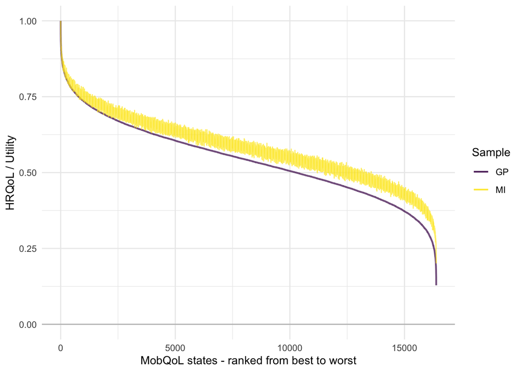

# 15 Distribution of utility values

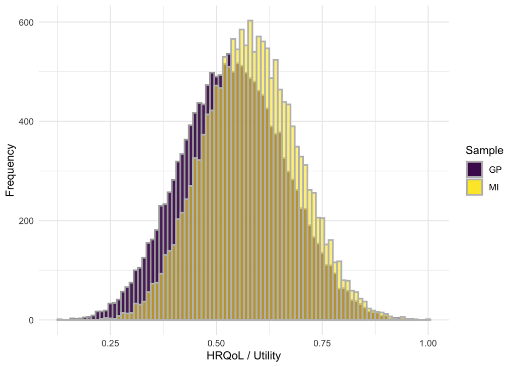

# 16 Value set table - GP vs MI, top and bottom 100 states (of all 16,384 states)

GP vs MI value sets

| Health state | GP utility | GP rank | MI utility | MI rank | Util diff | Rank diff |
| --- | --- | --- | --- | --- | --- | --- |
| 1111111 | 1.0000000 | 1 | 1.0000000 | 1 | 0.0000000 | 0 |
| 1112111 | 0.9669151 | 2 | 0.9616810 | 2 | 0.0052341 | 0 |
| 1111112 | 0.9559115 | 3 | 0.9584825 | 3 | -0.0025710 | 0 |
| 1111211 | 0.9541512 | 4 | 0.9546651 | 4 | -0.0005139 | 0 |
| 1211111 | 0.9460423 | 5 | 0.9446957 | 6 | 0.0013466 | -1 |
| 1111121 | 0.9449512 | 6 | 0.9502115 | 5 | -0.0052602 | 1 |
| 2111111 | 0.9367769 | 7 | 0.9436255 | 7 | -0.0068485 | 0 |
| 1121111 | 0.9320208 | 8 | 0.9394307 | 8 | -0.0074098 | 0 |
| 1111311 | 0.9316972 | 9 | 0.9366151 | 9 | -0.0049179 | 0 |
| 1113111 | 0.9280320 | 10 | 0.9361844 | 11 | -0.0081524 | -1 |
| 1111113 | 0.9267866 | 11 | 0.9362236 | 10 | -0.0094370 | 1 |
| 1112112 | 0.9228266 | 12 | 0.9201635 | 13 | 0.0026631 | -1 |
| 1112211 | 0.9210663 | 13 | 0.9163461 | 15 | 0.0047202 | -2 |
| 1311111 | 0.9180628 | 14 | 0.9176451 | 14 | 0.0004177 | 0 |
| 1111131 | 0.9159014 | 15 | 0.9296200 | 12 | -0.0137186 | 3 |
| 1212111 | 0.9129574 | 16 | 0.9063767 | 21 | 0.0065807 | -5 |
| 1112121 | 0.9118663 | 17 | 0.9118924 | 18 | -0.0000261 | -1 |
| 1111212 | 0.9100627 | 18 | 0.9131476 | 17 | -0.0030849 | 1 |
| 2112111 | 0.9036920 | 19 | 0.9053065 | 22 | -0.0016144 | -3 |
| 1211112 | 0.9019538 | 20 | 0.9031782 | 24 | -0.0012244 | -4 |
| 1111411 | 0.9019052 | 21 | 0.9024899 | 25 | -0.0005848 | -4 |
| 1111122 | 0.9008627 | 22 | 0.9086940 | 19 | -0.0078312 | 3 |
| 1211211 | 0.9001935 | 23 | 0.8993608 | 29 | 0.0008327 | -6 |
| 1111221 | 0.8991024 | 24 | 0.9048765 | 23 | -0.0057741 | 1 |
| 1111114 | 0.8989551 | 25 | 0.9065489 | 20 | -0.0075938 | 5 |
| 1122111 | 0.8989359 | 26 | 0.9011116 | 27 | -0.0021757 | -1 |
| 1112311 | 0.8986123 | 27 | 0.8982961 | 30 | 0.0003162 | -3 |
| 1112113 | 0.8937018 | 28 | 0.8979046 | 33 | -0.0042029 | -5 |
| 3111111 | 0.8936626 | 29 | 0.9148316 | 16 | -0.0211689 | 13 |
| 2111112 | 0.8926884 | 30 | 0.9021080 | 26 | -0.0094195 | 4 |

[output cut: 170 more lines]

```r
# write.csv(dual_vs, file = "./output/dual_vs.csv", row.names = F)
```